# DATA 613: Text Mining

Author

Ananya Rajan

## Part 1 – Load Required Libraries

- In this assignment, we use several R packages to perform text mining, sentiment analysis, data manipulation, and visualization.

  ```r
  # Load required libraries

  library(tidyverse)
  library(tidytext)
  library(janeaustenr)
  library(stringr)
  library(wordcloud)
  library(RColorBrewer)
  ```

- Explanation of the packages:
  - tidyverse: Data manipulation and visualization
  - tidytext: Text mining and sentiment analysis
  - janeaustenr: Provides Jane Austen’s books
  - stringr: Text processing and regular expressions
  - wordcloud: Creates word cloud visualizations
  - RColorBrewer: Provides color palettes

## Part 2 – Data Preparation: Loading the Dataset

- Data Preparation
  - In this section, we load Jane Austen’s books using the `janeaustenr` package and explore the available dataset. We will identify the different books and examine the structure of the text data.

  ```r
  # Load Jane Austen's books
  austen_data <- austen_books()

  # Display the first six rows
  head(austen_data)
  ```

  ```
  # A tibble: 6 × 2
    text                    book
    <chr>                   <fct>
  1 "SENSE AND SENSIBILITY" Sense & Sensibility
  2 ""                      Sense & Sensibility
  3 "by Jane Austen"        Sense & Sensibility
  4 ""                      Sense & Sensibility
  5 "(1811)"                Sense & Sensibility
  6 ""                      Sense & Sensibility
  ```

- Explanation:
  - austen_books() loads the collection of Jane Austen’s novels.
  - We store the dataset in an object called austen_data.
  - head() displays the first six rows so we can inspect the data.
- Explore the available books
  - The unique() function identifies the distinct book titles in the dataset. This allows us to confirm that Emma is included.

```r
# Display all available book titles
unique(austen_data$book)
```

```
[1] Sense & Sensibility Pride & Prejudice   Mansfield Park
[4] Emma                Northanger Abbey    Persuasion
6 Levels: Sense & Sensibility Pride & Prejudice Mansfield Park ... Persuasion
```

- Examine the dataset structure
  - glimpse() shows the columns and data types.
  - count(book) calculates how many text lines are available for each novel.

```r
# Examine the structure of the dataset
glimpse(austen_data)
```

```
Rows: 73,422
Columns: 2
$ text <chr> "SENSE AND SENSIBILITY", "", "by Jane Austen", "", "(1811)", "", …
$ book <fct> Sense & Sensibility, Sense & Sensibility, Sense & Sensibility, Se…
```

```r
# Count the number of lines for each book
austen_data %>%
  count(book)
```

```
# A tibble: 6 × 2
  book                    n
  <fct>               <int>
1 Sense & Sensibility 12624
2 Pride & Prejudice   13030
3 Mansfield Park      15349
4 Emma                16235
5 Northanger Abbey     7856
6 Persuasion           8328
```

## Part 3 – Extracting Emma and Chapter Detection

- In this section, we extract Jane Austen’s novel Emma from the complete dataset. We then use regular expressions to identify chapter headings and assign line numbers and chapter numbers to the text.

```r
# Extract Emma and identify chapter boundaries

emma <- austen_data %>%
  filter(book == "Emma") %>%
  mutate(
    linenumber = row_number(),
    chapter = cumsum(
      str_detect(
        text,
        regex("^chapter [\\divxlc]", ignore_case = TRUE)
      )
    )
  )

# Display the first few rows
head(emma)
```

```
# A tibble: 6 × 4
  text             book  linenumber chapter
  <chr>            <fct>      <int>   <int>
1 "EMMA"           Emma           1       0
2 ""               Emma           2       0
3 "By Jane Austen" Emma           3       0
4 ""               Emma           4       0
5 ""               Emma           5       0
6 ""               Emma           6       0
```

- Explanation of the code:
  - filter(): Selects only the novel Emma.
  - mutate(): Creates new columns.
  - row_number(): Assigns a sequential number to each line.
  - str_detect(): Detects chapter headings using a regular expression.
  - regex(): Makes chapter detection case-insensitive.
  - cumsum(): Increments the chapter number whenever a chapter heading is detected.
  - The regular expression “^chapter [\divxlc]”: looks for lines beginning with the word “Chapter” followed by a Roman numeral or digit.
- Check the chapter numbers
  - This helps verify that the chapter identification worked.

```r
# Check the number of chapters
max(emma$chapter)
```

```
[1] 55
```

```r
# Count lines in each chapter
emma %>%
  count(chapter)
```

```
# A tibble: 56 × 2
   chapter     n
     <int> <int>
 1       0    11
 2       1   328
 3       2   164
 4       3   179
 5       4   343
 6       5   202
 7       6   284
 8       7   260
 9       8   422
10       9   542
# ℹ 46 more rows
```

- Check the dataset structure

```r
# Examine the prepared Emma dataset
glimpse(emma)
```

```
Rows: 16,235
Columns: 4
$ text       <chr> "EMMA", "", "By Jane Austen", "", "", "", "", "VOLUME I", "…
$ book       <fct> Emma, Emma, Emma, Emma, Emma, Emma, Emma, Emma, Emma, Emma,…
$ linenumber <int> 1, 2, 3, 4, 5, 6, 7, 8, 9, 10, 11, 12, 13, 14, 15, 16, 17, …
$ chapter    <int> 0, 0, 0, 0, 0, 0, 0, 0, 0, 0, 0, 1, 1, 1, 1, 1, 1, 1, 1, 1,…
```

```r
# Display the first 10 rows
emma %>%
  select(book, linenumber, chapter, text) %>%
  head(10)
```

```
# A tibble: 10 × 4
   book  linenumber chapter text
   <fct>      <int>   <int> <chr>
 1 Emma           1       0 "EMMA"
 2 Emma           2       0 ""
 3 Emma           3       0 "By Jane Austen"
 4 Emma           4       0 ""
 5 Emma           5       0 ""
 6 Emma           6       0 ""
 7 Emma           7       0 ""
 8 Emma           8       0 "VOLUME I"
 9 Emma           9       0 ""
10 Emma          10       0 ""
```

## Part 4 – Tokenization

- Tokenization is the process of breaking text into smaller units called tokens. In this assignment, we use the `unnest_tokens()` function from the tidytext package to separate Emma’s text into individual words.

```r
# Tokenize Emma's text into individual words

emma_words <- emma %>%
  unnest_tokens(word, text)

# Display the first few words
head(emma_words)
```

```
# A tibble: 6 × 4
  book  linenumber chapter word
  <fct>      <int>   <int> <chr>
1 Emma           1       0 emma
2 Emma           3       0 by
3 Emma           3       0 jane
4 Emma           3       0 austen
5 Emma           8       0 volume
6 Emma           8       0 i
```

- Explanation of the code:
  - emma %>% passes the Emma dataset to the next operation.
  - unnest_tokens(word, text) separates the text into individual words.
  - word is the name of the new column containing individual words.
  - text is the original column containing the book’s text.
  - emma_words stores the resulting tokenized dataset.
- Examine the tokenized dataset

```r
# Examine the tokenized dataset
glimpse(emma_words)
```

```
Rows: 160,996
Columns: 4
$ book       <fct> Emma, Emma, Emma, Emma, Emma, Emma, Emma, Emma, Emma, Emma,…
$ linenumber <int> 1, 3, 3, 3, 8, 8, 12, 12, 15, 15, 15, 15, 15, 15, 15, 15, 1…
$ chapter    <int> 0, 0, 0, 0, 0, 0, 1, 1, 1, 1, 1, 1, 1, 1, 1, 1, 1, 1, 1, 1,…
$ word       <chr> "emma", "by", "jane", "austen", "volume", "i", "chapter", "…
```

```r
# Count the total number of words
nrow(emma_words)
```

```
[1] 160996
```

```r
# Display the 20 most frequent words
emma_words %>%
  count(word, sort = TRUE) %>%
  head(20)
```

```
# A tibble: 20 × 2
   word      n
   <chr> <int>
 1 to     5239
 2 the    5201
 3 and    4896
 4 of     4291
 5 i      3177
 6 a      3129
 7 it     2528
 8 her    2462
 9 was    2398
10 she    2340
11 in     2189
12 not    2140
13 you    1980
14 be     1975
15 he     1806
16 that   1788
17 had    1624
18 but    1441
19 as     1436
20 for    1347
```

- Explanation of the code:
  - glimpse() examines the dataset structure.
  - nrow() counts the total number of word tokens.
  - count(word, sort = TRUE) calculates word frequencies and sorts them from highest to lowest.
  - head(20) displays the 20 most frequent words.

## Part 5 – Sentiment Analysis

- The NRC sentiment lexicon categorizes words according to different emotions and sentiments. In this section, we focus on words associated with joy to explore joyful language in Jane Austen’s Emma.

```r
# Load required libraries
library(textdata)

# Filter NRC lexicon for joy
nrc_joy <- get_sentiments("nrc") %>%
  filter(sentiment == "joy")

# Join with Emma's words and count frequency
emma_nrc <- emma_words %>%
  inner_join(nrc_joy, by = "word") %>%
  count(word, sort = TRUE)

# Keep frequently occurring words (n > 50)
emma_nrc_filtered <- emma_nrc %>%
  filter(n > 50)

# Display results
head(emma_nrc_filtered, 20)
```

```
# A tibble: 18 × 2
   word          n
   <chr>     <int>
 1 good        359
 2 friend      166
 3 hope        143
 4 happy       125
 5 love        117
 6 deal         92
 7 found        92
 8 present      89
 9 kind         82
10 happiness    76
11 pretty       68
12 true         66
13 comfort      65
14 spirits      64
15 marry        63
16 mother       57
17 feeling      56
18 satisfied    52
```

- AFINN — Positive scores

```r
# Filter AFINN lexicon for positive scores (>= 1)
afinn_positive <- get_sentiments("afinn") %>%
  filter(value >= 1)

# Join with Emma's words and count frequency
emma_afinn <- emma_words %>%
  inner_join(afinn_positive, by = "word") %>%
  count(word, sort = TRUE)

# Keep frequently occurring words
emma_afinn_filtered <- emma_afinn %>%
  filter(n > 50)

head(emma_afinn_filtered, 20)
```

```
# A tibble: 20 × 2
   word          n
   <chr>     <int>
 1 good        359
 2 great       264
 3 dear        241
 4 like        200
 5 better      173
 6 hope        143
 7 wish        135
 8 happy       125
 9 yes         125
10 love        117
11 pleasure    115
12 want         90
13 best         85
14 kind         82
15 happiness    76
16 pretty       68
17 perfectly    67
18 true         66
19 comfort      65
20 superior     59
```

- Bing — Positive words

```r
# Filter Bing lexicon for positive words
bing_positive <- get_sentiments("bing") %>%
  filter(sentiment == "positive")

# Join with Emma's words and count frequency
emma_bing <- emma_words %>%
  inner_join(bing_positive, by = "word") %>%
  count(word, sort = TRUE)

# Keep frequently occurring words
emma_bing_filtered <- emma_bing %>%
  filter(n > 50)

head(emma_bing_filtered, 20)
```

```
# A tibble: 19 × 2
   word          n
   <chr>     <int>
 1 well        401
 2 good        359
 3 great       264
 4 like        200
 5 better      173
 6 enough      129
 7 happy       125
 8 love        117
 9 pleasure    115
10 right        92
11 best         85
12 happiness    76
13 pretty       68
14 perfectly    67
15 ready        66
16 comfort      65
17 assure       59
18 superior     59
19 satisfied    52
```

## Part 6 – Visualization

- Bar charts using ggplot2

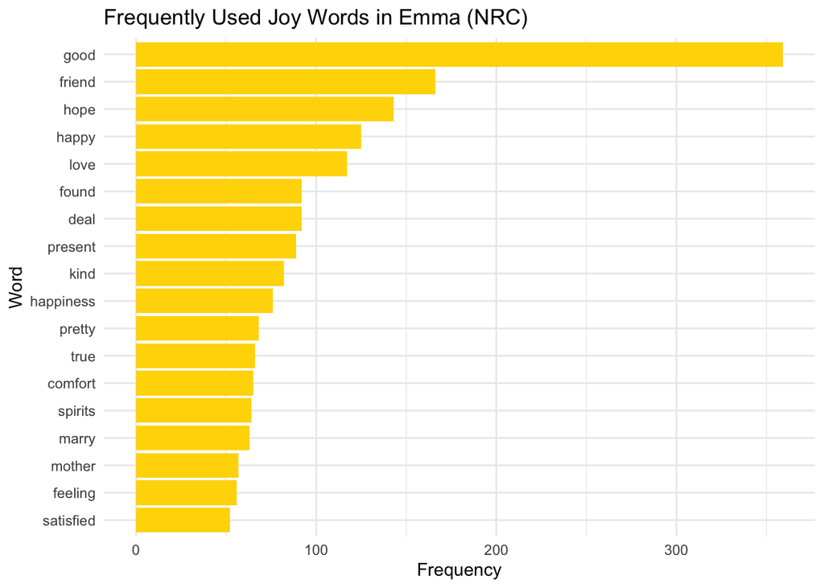

```r
# NRC joy bar chart
ggplot(emma_nrc_filtered,
       aes(x = reorder(word, n), y = n)) +
  geom_col(fill = "gold") +
  coord_flip() +
  labs(
    title = "Frequently Used Joy Words in Emma (NRC)",
    x = "Word",
    y = "Frequency"
  ) +
  theme_minimal()
```

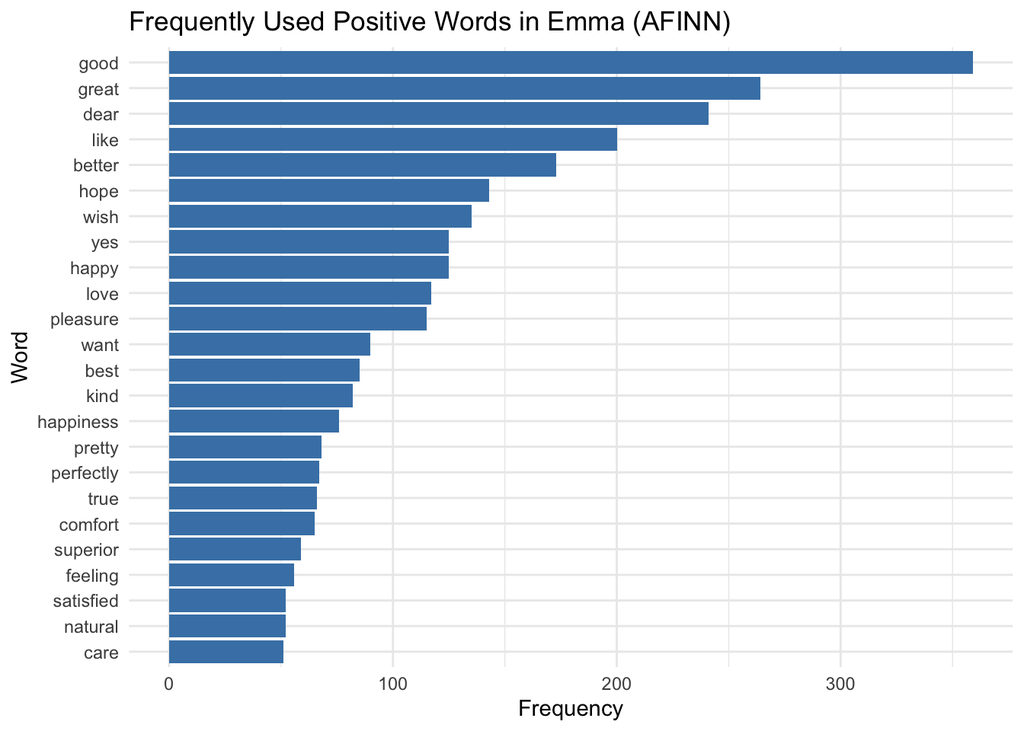

```r
# AFINN positive bar chart
ggplot(emma_afinn_filtered,
       aes(x = reorder(word, n), y = n)) +
  geom_col(fill = "steelblue") +
  coord_flip() +
  labs(
    title = "Frequently Used Positive Words in Emma (AFINN)",
    x = "Word",
    y = "Frequency"
  ) +
  theme_minimal()
```

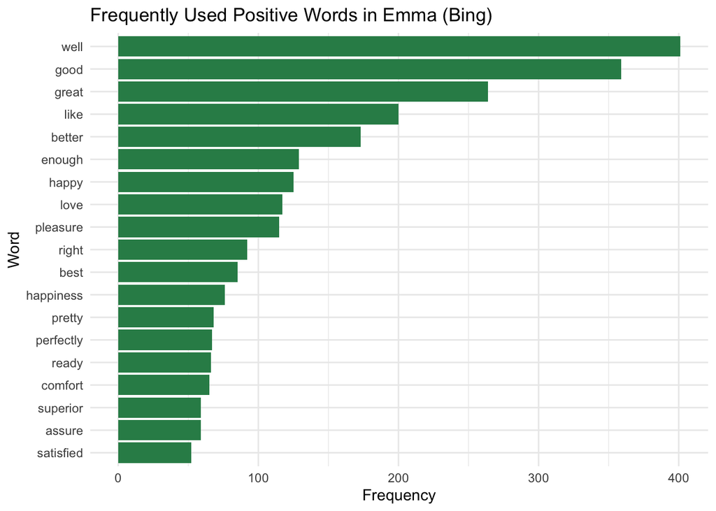

```r
# Bing positive bar chart
ggplot(emma_bing_filtered,
       aes(x = reorder(word, n), y = n)) +
  geom_col(fill = "seagreen") +
  coord_flip() +
  labs(
    title = "Frequently Used Positive Words in Emma (Bing)",
    x = "Word",
    y = "Frequency"
  ) +
  theme_minimal()
```

- Word clouds

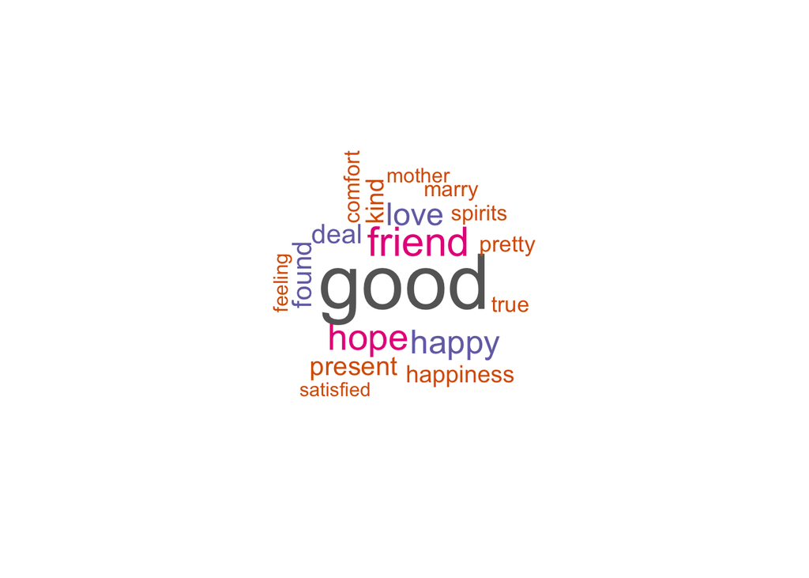

```r
# NRC joy word cloud
wordcloud(
  words = emma_nrc_filtered$word,
  freq = emma_nrc_filtered$n,
  max.words = 100,
  random.order = FALSE,
  colors = brewer.pal(8, "Dark2")
)
```

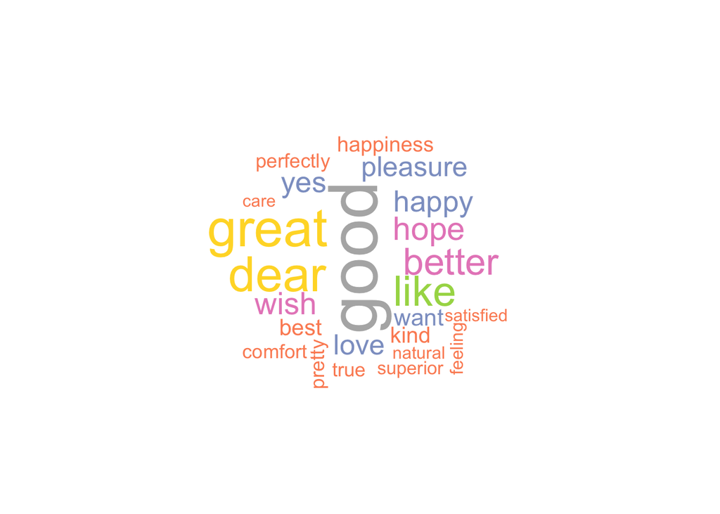

```r
# AFINN positive word cloud
wordcloud(
  words = emma_afinn_filtered$word,
  freq = emma_afinn_filtered$n,
  max.words = 100,
  random.order = FALSE,
  colors = brewer.pal(8, "Set2")
)
```

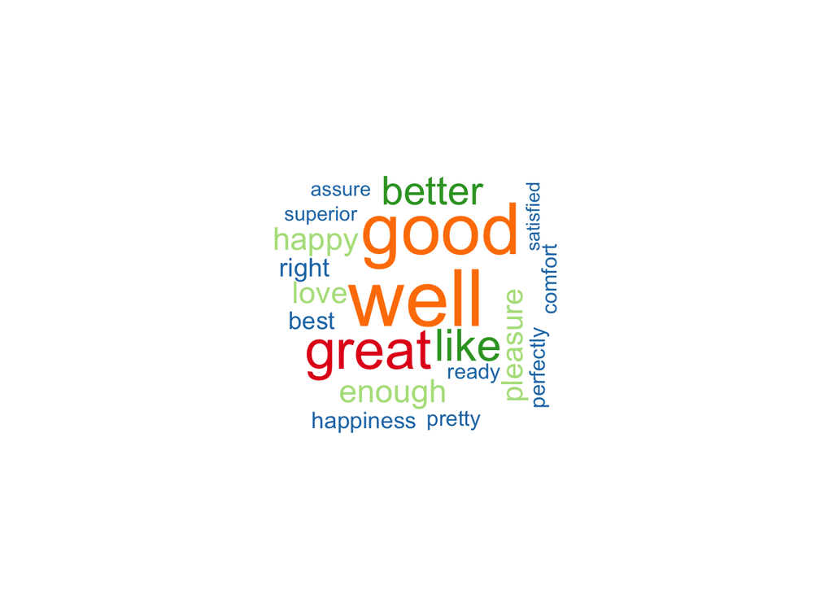

```r
# Bing positive word cloud
wordcloud(
  words = emma_bing_filtered$word,
  freq = emma_bing_filtered$n,
  max.words = 100,
  random.order = FALSE,
  colors = brewer.pal(8, "Paired")
)
```